title: “HW 3: R and RMarkdown Basics” author: “Aman Jaglan” date: “2023-09-05” output: html_document: code_folding: hide number_sections: false toc: yes toc_depth: 3 toc_float: yes pdf_document: toc: yes toc_depth: ‘3’

# Read-in the data

First I am going to read the csv file by using read.csv function from my local directory.

```r
baseball = read.csv("BaseballHeightWeight.csv", header = TRUE)
str(baseball)
```

```
## 'data.frame':    1034 obs. of  6 variables:
##  $ Name          : chr  "Adam_Donachie" "Paul_Bako" "Ramon_Hernandez" "Kevin_Millar" ...
##  $ Team          : chr  "BAL" "BAL" "BAL" "BAL" ...
##  $ Position      : chr  "Catcher" "Catcher" "Catcher" "First_Baseman" ...
##  $ Height.inches.: int  74 74 72 72 73 69 69 71 76 71 ...
##  $ Weight.pounds.: int  180 215 210 210 188 176 209 200 231 180 ...
##  $ Age           : num  23 34.7 30.8 35.4 35.7 ...
```

# Quick look at the data frame.

```r
head(baseball, n=5)
```

```
##              Name Team      Position Height.inches. Weight.pounds.   Age
## 1   Adam_Donachie  BAL       Catcher             74            180 22.99
## 2       Paul_Bako  BAL       Catcher             74            215 34.69
## 3 Ramon_Hernandez  BAL       Catcher             72            210 30.78
## 4    Kevin_Millar  BAL First_Baseman             72            210 35.43
## 5     Chris_Gomez  BAL First_Baseman             73            188 35.71
```

```r
tail(baseball,n=3)
```

```
##                Name Team       Position Height.inches. Weight.pounds.   Age
## 1032 Chris_Narveson  STL Relief_Pitcher             75            205 25.19
## 1033  Randy_Keisler  STL Relief_Pitcher             75            190 31.01
## 1034    Josh_Kinney  STL Relief_Pitcher             73            195 27.92
```

# Change variable/column names.

```r
colnames(baseball)[4] <- "height"
colnames(baseball)[5] <- "weight"
colnames(baseball)[6] <- "age"
```

# Quick look at the modified data frame.

```r
head(baseball, n=2)
```

```
##            Name Team Position height weight   age
## 1 Adam_Donachie  BAL  Catcher     74    180 22.99
## 2     Paul_Bako  BAL  Catcher     74    215 34.69
```

# Summary statistics.

```r
library(ezids)
players <- baseball[,c("height","weight","age")]
str(players)
```

```
## 'data.frame':    1034 obs. of  3 variables:
##  $ height: int  74 74 72 72 73 69 69 71 76 71 ...
##  $ weight: int  180 215 210 210 188 176 209 200 231 180 ...
##  $ age   : num  23 34.7 30.8 35.4 35.7 ...
```

```r
summary(players)
```

```
##      height         weight           age
##  Min.   :67.0   Min.   :150.0   Min.   :20.90
##  1st Qu.:72.0   1st Qu.:187.0   1st Qu.:25.44
##  Median :74.0   Median :200.0   Median :27.93
##  Mean   :73.7   Mean   :201.7   Mean   :28.74
##  3rd Qu.:75.0   3rd Qu.:215.0   3rd Qu.:31.23
##  Max.   :83.0   Max.   :290.0   Max.   :48.52
##                 NA's   :1
```

Now the dataset is contains some null values that’s why the xkablesummary is not working it’s giving error. first we need to get rid of the null values then we can use xkablesummary for gettting summary. Until we clean our dataset we can use summary to get the overview of the dataset.

# Selecting observations with missing values.

```r
subset(players, is.na(weight))
```

```
##     height weight   age
## 641     72     NA 27.77
```

As we can see there are only one row which contains null value.

# Defining a subset.

```r
players <- subset(players, !is.na(weight))
nrow(players)
```

```
## [1] 1033
```

There are 1033 observation left after cleaning the na values from weight data set.

```r
xkablesummary(players)
```

Table: Statistics summary.

|  | height | weight | age |
| --- | --- | --- | --- |
| Min | Min. :67.0 | Min. :150.0 | Min. :20.90 |
| Q1 | 1st Qu.:72.0 | 1st Qu.:187.0 | 1st Qu.:25.44 |
| Median | Median :74.0 | Median :200.0 | Median :27.93 |
| Mean | Mean :73.7 | Mean :201.7 | Mean :28.74 |
| Q3 | 3rd Qu.:75.0 | 3rd Qu.:215.0 | 3rd Qu.:31.24 |
| Max | Max. :83.0 | Max. :290.0 | Max. :48.52 |

Now, we cleaned out the dataset there is no more null values. we can use the xkablesummary function for getting the overview of the dataset.

# Boxplot for continuous variable.

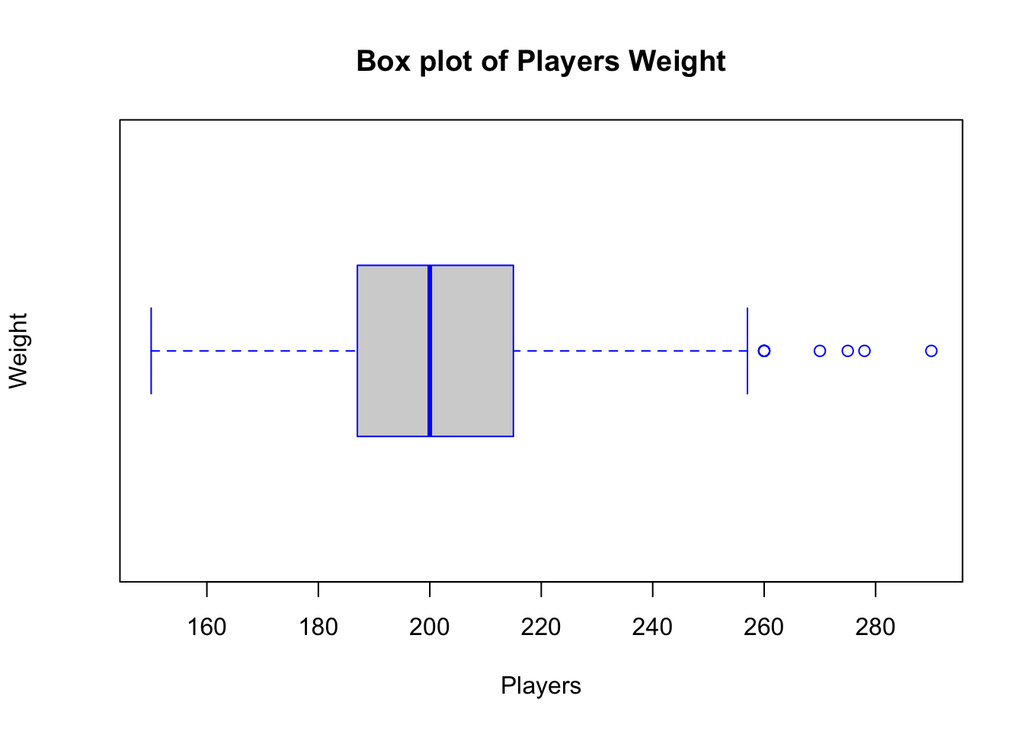

```r
boxplot(
  players$weight,
  main = "Box plot of Players Weight",
  xlab = "Players",
  ylab = "Weight",
  border = "blue",
  horizontal = TRUE
  )
```

# ggplot for the same observation

For using ggplot first we need to install ggplot2 package.Then we can use the ggplot function for plotting graphs.

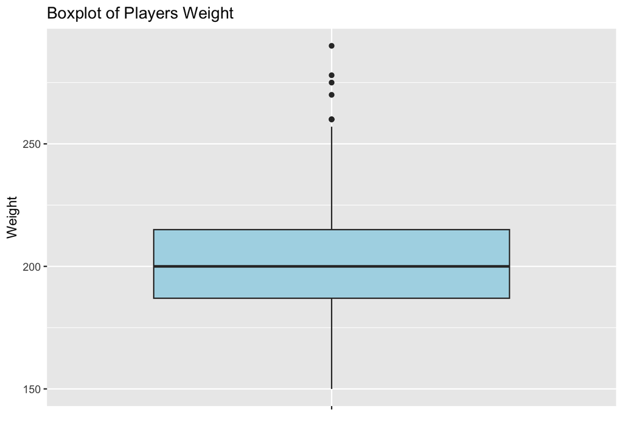

```r
library("ggplot2")
ggplot(data = players, aes(x = "", y = weight)) +
   geom_boxplot(fill = "lightblue") +
   labs(title = "Boxplot of Players Weight",
       x = "",
       y = "Weight")
```

I would prefer ggplot. because I get lot’s of option for visualizing a data.

# Histogram for continuous variable.

First plot is drwan by using the hist function.

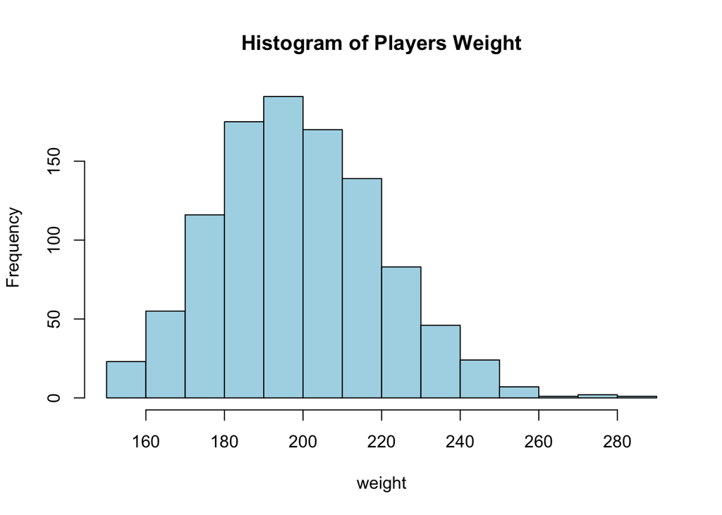

```r
hist(players$weight,
     main = "Histogram of Players Weight",
     xlab = "weight",
     ylab = "Frequency",
     col = "lightblue")
```

The histogram created using the base R hist function shows a distribution of player weights. In this example, the histogram has a roughly symmetrical shape, with a peak around the middle values of the weight range. It resembles a normal distribution, although it’s not perfectly symmetric. There are fewer observations on the higher end of the weight range, resulting in a slightly right-skewed tail.

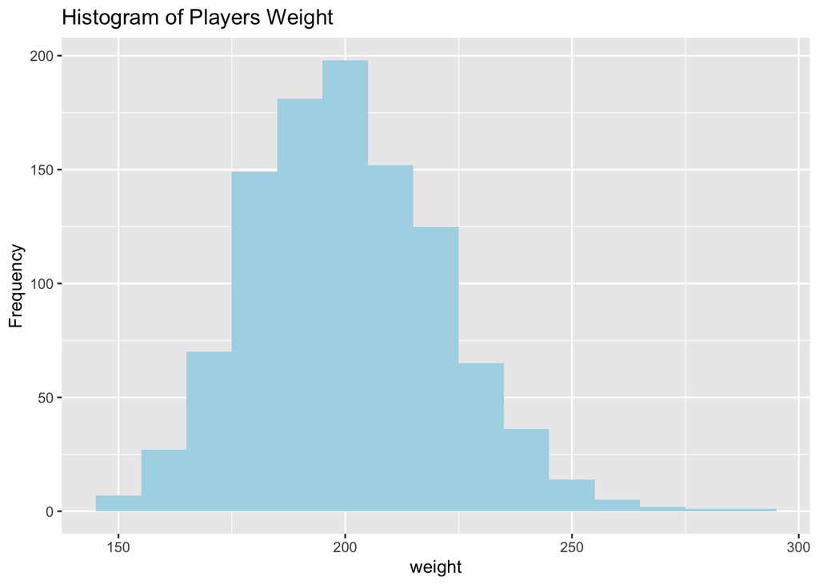

```r
ggplot(data = players, aes(x = weight)) +
  geom_histogram(fill = "lightblue", binwidth = 10) +
  labs(title = "Histogram of Players Weight",
       x = "weight",
       y = "Frequency")
```

The histogram created using ggplot2 also shows the distribution of player weights. It has a similar shape to the base R histogram, with a peak around the middle values. The distribution appears to be slightly right-skewed, with a longer tail on the right side of the peak. This indicates that there are fewer players with very higher weights compared to those with less weights.

# Scatterplot for two continuous variables by a categorical variable.

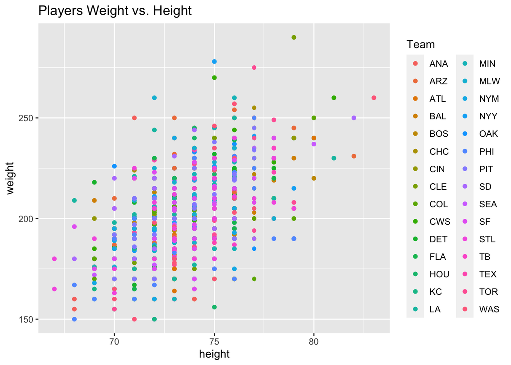

```r
ggplot(data = baseball, aes(x = height, y = weight, color = Team)) +
  geom_point() +
  labs(title = "Players Weight vs. Height",
       x = "height",
       y = "weight")
```

# Scatterplot for two continuous variables by a continuous variable.

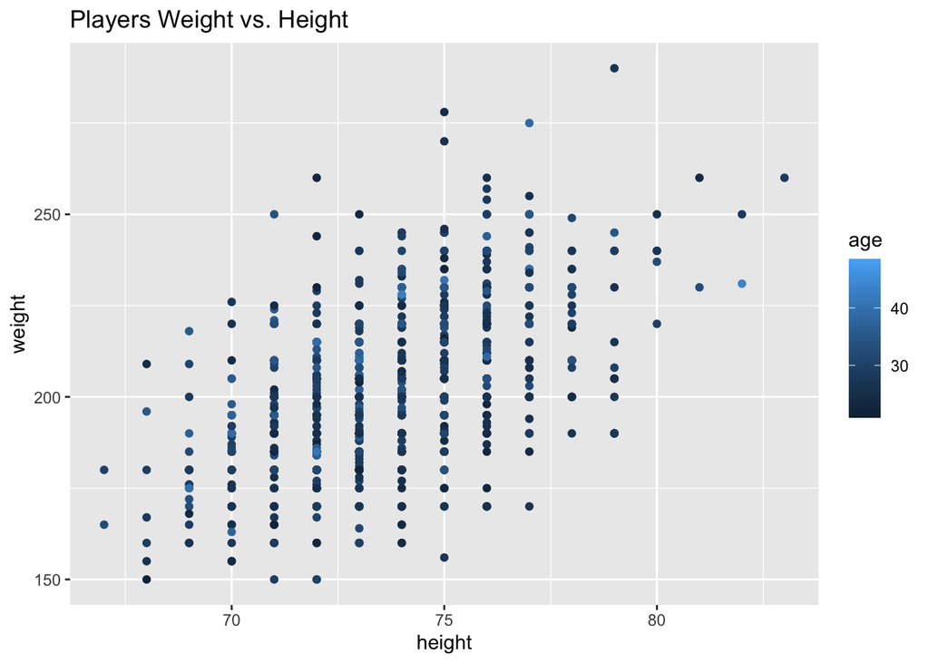

```r
ggplot(data = baseball, aes(x = height, y = weight, color = age)) +
  geom_point() +
  labs(title = "Players Weight vs. Height",
       x = "height",
       y = "weight")
```

# Defining a subset.

```r
WashingtonPlayers <- subset(baseball, Team == "WAS")
str(WashingtonPlayers)
```

```
## 'data.frame':    36 obs. of  6 variables:
##  $ Name    : chr  "Brian_Schneider" "Jesus_Flores" "Larry_Broadway" "Nick_Johnson" ...
##  $ Team    : chr  "WAS" "WAS" "WAS" "WAS" ...
##  $ Position: chr  "Catcher" "Catcher" "First_Baseman" "First_Baseman" ...
##  $ height  : int  73 73 76 75 70 73 72 73 75 74 ...
##  $ weight  : int  196 180 230 224 160 178 205 185 210 180 ...
##  $ age     : num  30.3 22.3 26.2 28.4 27.6 ...
```

There are total 36 players in Team Washington.

# Defining a subset.

```r
experiencedTeam <- subset(WashingtonPlayers, age > 28)
str(experiencedTeam)
```

```
## 'data.frame':    14 obs. of  6 variables:
##  $ Name    : chr  "Brian_Schneider" "Nick_Johnson" "Cristian_Guzman" "Ryan_Church" ...
##  $ Team    : chr  "WAS" "WAS" "WAS" "WAS" ...
##  $ Position: chr  "Catcher" "First_Baseman" "Shortstop" "Outfielder" ...
##  $ height  : int  73 75 72 73 76 73 72 77 75 71 ...
##  $ weight  : int  196 224 205 190 257 190 200 208 210 150 ...
##  $ age     : num  30.3 28.4 28.9 28.4 28.2 ...
```

There are 14 players in the Team Washington whose age is greater than 28.